# Data Description

## Model Evaluation

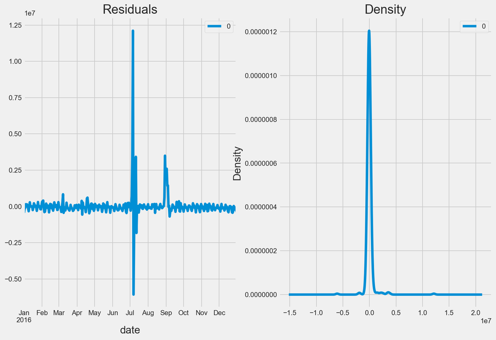

```python
# Plot residual errors
residuals = pd.DataFrame(results_arima100.resid)
fig, ax = plt.subplots(1,2,figsize=(12,8))
residuals.plot(title="Residuals", ax=ax[0])
residuals.plot(kind='kde', title='Density', ax=ax[1])
plt.show()
```

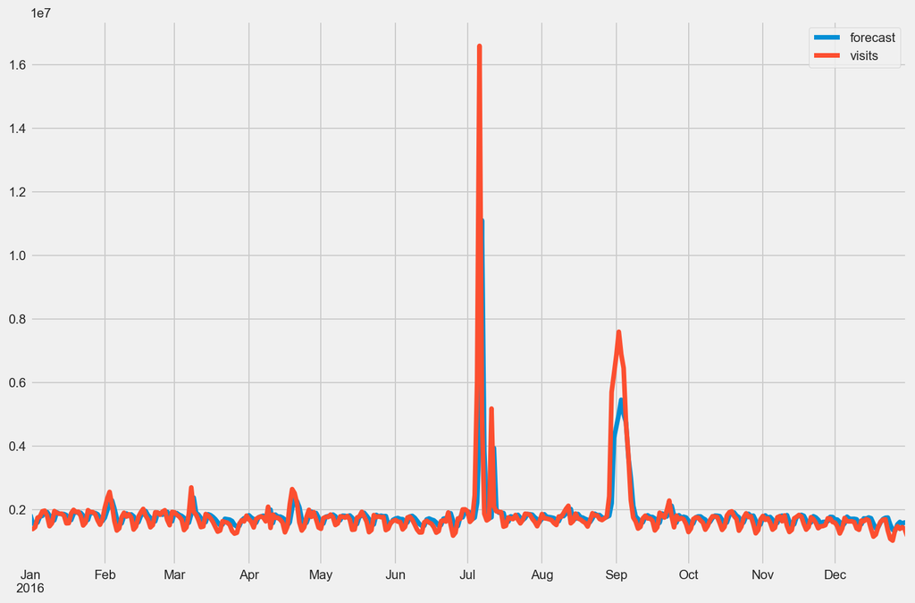

```python
# Actual vs Fitted
results_arima100.plot_predict(dynamic=False)
plt.show()
```

```python
# Accuracy metrics
def timeseries_evaluation(ytest, ypreds, df_eval=None,show=False,
                          round_=2,index_name=None):
    from statsmodels.tsa.stattools import acf

    if not isinstance(df_eval, pd.DataFrame):
        df_eval = pd.DataFrame({'MAPE': [],
                                'ME': [],
                                'MAE': [],
                                'MPE': [],
                                'RMSE': [],
                                'CORR': [],
                                'MINMAX': [],
                                'ACF1': [],
                                })

    mape = np.mean(np.abs(ypreds - ytest)/np.abs(ytest))  # MAPE
    me = np.mean(ypreds - ytest)             # ME
    mae = np.mean(np.abs(ypreds - ytest))    # MAE
    mpe = np.mean((ypreds - ytest)/ytest)   # MPE
    rmse = np.mean((ypreds - ytest)**2)**.5  # RMSE
    corr = np.corrcoef(ypreds, ytest)[0, 1]   # corr
    mins = np.amin(np.hstack([ypreds[:, None],
                              ytest[:, None]]), axis=1)
    maxs = np.amax(np.hstack([ypreds[:, None],
                              ytest[:, None]]), axis=1)
    minmax = 1 - np.mean(mins/maxs)             # minmax

    acf1 = acf(ypreds-ytest, fft=False)[1]    # ACF1

    row = [mape, me, mae, mpe, rmse, corr, minmax, acf1]

    if index_name:
        df_eval.loc[index_name] =  row

    else:
        df_eval.loc[len(df_eval)] = row

    df_eval = df_eval.round(round_)

    if show:
        display(df_eval)
    return df_eval
```

```python
# 1,0,0 AR Model
train = ts.iloc[:300]
model = ARIMA(train, order=(1,0,0))
results_arima100 = model.fit(disp=0)
```

```python
# Forecast
test =  ts.iloc[300:]
fc, se, conf = results_arima100.forecast(len(test), alpha=0.05)  # 95% conf
timeseries_evaluation(test, fc)
```

|  | MAPE | ME | MAE | MPE | RMSE | CORR | MINMAX | ACF1 |
| --- | --- | --- | --- | --- | --- | --- | --- | --- |
| 0 | 0.26 | 372279.08 | 372279.08 | 0.26 | 420198.17 | -0.09 | 0.19 | 0.53 |

```python
# https://github.com/statsmodels/statsmodels/blob/master/examples/notebooks/tsa_arma_0.ipynb

arma10 = sm.tsa.ARMA(train, (1,0)).fit(disp=False)
resid = arma10.resid

print(train.shape, resid.shape)
r,q,p = sm.tsa.acf(resid, fft=True, qstat=True)
print(r.shape, q.shape, p.shape)

data = np.c_[range(1,len(r)), r[1:], q, p]

table = pd.DataFrame(data, columns=['lag', "AC", "Q", "Prob(>Q)"])
table.set_index('lag').head()
```

```
(300,) (300,)
(41,) (40,) (40,)
```

| lag | AC | Q | Prob(>Q) |
| --- | --- | --- | --- |
| 1.0 | 0.042116 | 0.537471 | 0.463483 |
| 2.0 | -0.065968 | 1.860518 | 0.394451 |
| 3.0 | -0.028170 | 2.102594 | 0.551388 |
| 4.0 | -0.059243 | 3.176863 | 0.528676 |
| 5.0 | 0.206869 | 16.319908 | 0.005988 |

# Auto ARIMA

```python
from statsmodels.tsa.arima_model import ARIMA
import pmdarima as pm
```

```python
model = pm.auto_arima(ts, start_p=1, start_q=1,
                      test='adf',       # use adftest to find optimal 'd'
                      max_p=3, max_q=3, # maximum p and q
                      m=1,              # frequency of series
                      d=None,           # let model determine 'd'
                      seasonal=False,   # No Seasonality
                      start_P=0,
                      D=0,
                      trace=True,
                      error_action='ignore',
                      suppress_warnings=True,
                      stepwise=True)

model.summary()
```

```
Performing stepwise search to minimize aic
 ARIMA(1,0,1)(0,0,0)[0]             : AIC=11092.335, Time=0.07 sec
 ARIMA(0,0,0)(0,0,0)[0]             : AIC=11712.531, Time=0.01 sec
 ARIMA(1,0,0)(0,0,0)[0]             : AIC=11095.687, Time=0.02 sec
 ARIMA(0,0,1)(0,0,0)[0]             : AIC=11475.698, Time=0.04 sec
 ARIMA(2,0,1)(0,0,0)[0]             : AIC=11090.849, Time=0.36 sec
 ARIMA(2,0,0)(0,0,0)[0]             : AIC=11094.755, Time=0.02 sec
 ARIMA(3,0,1)(0,0,0)[0]             : AIC=inf, Time=0.28 sec
 ARIMA(2,0,2)(0,0,0)[0]             : AIC=inf, Time=0.42 sec
 ARIMA(1,0,2)(0,0,0)[0]             : AIC=11064.631, Time=0.07 sec
 ARIMA(0,0,2)(0,0,0)[0]             : AIC=11432.449, Time=0.03 sec
 ARIMA(1,0,3)(0,0,0)[0]             : AIC=11061.297, Time=0.16 sec
 ARIMA(0,0,3)(0,0,0)[0]             : AIC=11397.376, Time=0.05 sec
 ARIMA(2,0,3)(0,0,0)[0]             : AIC=11062.418, Time=0.17 sec
 ARIMA(1,0,3)(0,0,0)[0] intercept   : AIC=11042.894, Time=0.08 sec
 ARIMA(0,0,3)(0,0,0)[0] intercept   : AIC=11050.512, Time=0.05 sec
 ARIMA(1,0,2)(0,0,0)[0] intercept   : AIC=11040.693, Time=0.07 sec
 ARIMA(0,0,2)(0,0,0)[0] intercept   : AIC=11066.585, Time=0.08 sec
 ARIMA(1,0,1)(0,0,0)[0] intercept   : AIC=11040.158, Time=0.03 sec
 ARIMA(0,0,1)(0,0,0)[0] intercept   : AIC=11084.832, Time=0.03 sec
 ARIMA(1,0,0)(0,0,0)[0] intercept   : AIC=11039.466, Time=0.03 sec
 ARIMA(0,0,0)(0,0,0)[0] intercept   : AIC=11221.532, Time=0.01 sec
 ARIMA(2,0,0)(0,0,0)[0] intercept   : AIC=11040.000, Time=0.05 sec
 ARIMA(2,0,1)(0,0,0)[0] intercept   : AIC=11042.104, Time=0.13 sec

Best model:  ARIMA(1,0,0)(0,0,0)[0] intercept
Total fit time: 2.281 seconds
```

SARIMAX Results

| Dep. Variable: | y | No. Observations: | 366 |
| --- | --- | --- | --- |
| Model: | SARIMAX(1, 0, 0) | Log Likelihood | -5516.733 |
| Date: | Wed, 14 Oct 2020 | AIC | 11039.466 |
| Time: | 12:09:15 | BIC | 11051.174 |
| Sample: | 0 | HQIC | 11044.118 |
|  | - 366 |  |  |
| Covariance Type: | opg |  |  |

|  | coef | std err | z | P>\|z\| | [0.025 | 0.975] |
| --- | --- | --- | --- | --- | --- | --- |
| intercept | 6.839e+05 | 8.28e+04 | 8.256 | 0.000 | 5.22e+05 | 8.46e+05 |
| ar.L1 | 0.6284 | 0.010 | 60.466 | 0.000 | 0.608 | 0.649 |
| sigma2 | 7.248e+11 | 0.690 | 1.05e+12 | 0.000 | 7.25e+11 | 7.25e+11 |

| Ljung-Box (Q): | 27.43 | Jarque-Bera (JB): | 222704.07 |
| --- | --- | --- | --- |
| Prob(Q): | 0.93 | Prob(JB): | 0.00 |
| Heteroskedasticity (H): | 3.28 | Skew: | 7.63 |
| Prob(H) (two-sided): | 0.00 | Kurtosis: | 122.88 |

Warnings:  
[1] Covariance matrix calculated using the outer product of gradients (complex-step).  
[2] Covariance matrix is singular or near-singular, with condition number 2.84e+39. Standard errors may be unstable.

## Interpret the residual plots in ARIMA model

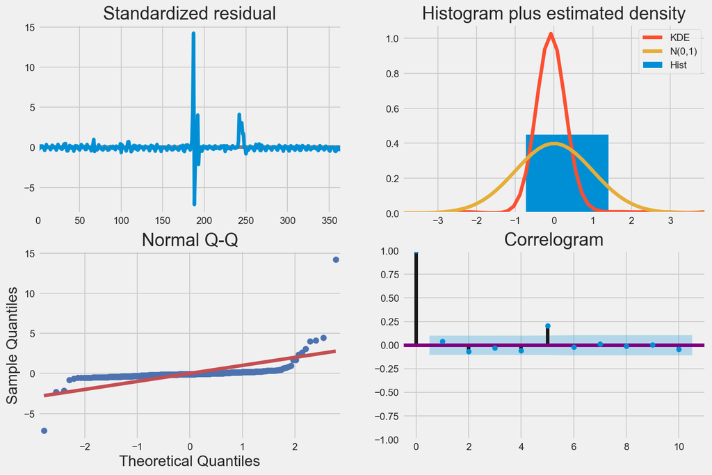

```python
model.plot_diagnostics(figsize=(12,8))
plt.show()
```

Plot diagnostics:

> Fig2 : In the top right plot, we see that the red KDE line does NOT follow closely with the normal distribution N(0,1) line. So the residuals are NOT normally distributed. NOT Good.

> Fig3: The qq-plot on the bottom left shows that the ordered distribution of residuals (blue dots) does NOT follow the linear trend of the samples taken from a standard normal distribution with N(0, 1). Again, this is a strong indication that the residuals are NOT normally distributed.

Meaning: Our fitting is not so good.  
Further work: We may want to normalize the data. We may want do deal with outliers.